# AcceptReject: An R Package for Acceptance-Rejection Method

The AcceptReject package, available for the R programming language on the Comprehensive R Archive Network (CRAN), versioned and maintained on GitHub, offers a simple and efficient solution for generating pseudo-random observations of discrete or continuous random variables using the acceptance-rejection method. This method provides a viable alternative for generating pseudo-random observations in univariate distributions when the inverse of the cumulative distribution function is not in closed form or when suitable transformations involving random variables that we know how to generate are unknown, thereby facilitating the generation of observations for the variable of interest. The package is designed to be simple, intuitive, and efficient, allowing for the rapid generation of observations and supporting multicore parallelism on Unix-based operating systems. Some components are written using C++, and the package maximizes the acceptance probability of the generated observations, resulting in even more efficient execution. The package also allows users to explore the generated pseudo-random observations by comparing them with the theoretical probability mass function or probability density function and to inspect the underlying probability density functions that can be used in the method for generating observations of continuous random variables. This article explores the package in detail, discussing its functionalities, benefits, and practical applications, and provides various benchmarks in several scenarios.

Pedro Rafael Diniz Marinho https://github.com/prdm0 (Federal University of Paraíba) , Vera L. D. Tomazella https://www.servidores.ufscar.br/vera/ (Federal University of São Carlos)  
2025-12-31

## 1 Introduction

The class of Monte Carlo methods and algorithms is a powerful and versatile computational technique that has been widely used in a variety of fields, from physics, statistics, and economics to biology and areas such as social sciences. Through the modeling of complex systems and the performance of stochastic experiments, Monte Carlo simulation allows researchers to explore scenarios that would be impractical or impossible to investigate through traditional experimental methods.

A critical component of any Monte Carlo simulation is the ability to generate pseudo-random observations of a sequence of random variables that follow a given probability distribution. In many cases, these variables can be discrete or continuous, and the ability to generate observations from a sequence of random variables efficiently and accurately is fundamental in simulation studies.

There are several techniques to generate observations from a sequence of random variables, many of which depend on the availability of a closed-form quantile function of the distribution of interest or knowledge of some transformation involving random variables that we know how to generate observations from. Depending on the distribution one wishes to generate observations from, the inverse of the cumulative distribution function (quantile function) does not have a closed form, and in many cases, we do not know transformations involving random variables that we know how to generate observations from, and thus, we can generate observations from the random variable of interest. In this sense, computational methods, such as the Acceptance-Rejection Method (ARM), proposed by John von Neumann in 1951, see von Neumann (1951), are a viable alternative for generating observations in the univariate context. For example, in the current scenario, where various distributions and probability distribution generators are being proposed, with these generators being functions that, from the knowledge of a probability distribution, can generate a new probability distribution, the ARM is widely used because it proves to be useful for generating pseudo-random observations of random variables of a discrete or continuous nature.

In the case of univariate distributions, the ARM is an effective technique for generating pseudo-random observations of random variables and has several advantages over other methods such as the Metropolis-Hastings (MH) algorithm, for example. The ARM, often also called the Rejection Method, is an algorithm that can be easily parallelized. Moreover, this method is not sensitive to initial parameters, as in the case of the MH algorithm, and leads to observations that are not dependent. Additionally, in the ARM, it is not necessary to perform a “burn-in,” and it is not required to wait for the algorithm to reach a stationary level, as in the case of MH. The ARM, when well implemented, can be a great alternative for generating observations of random variables in the univariate case and can be considered in many situations before opting for computationally more expensive methods such as MH or Gibbs sampling.

The AcceptReject package (Marinho and Tomazella 2024) for the R programming language, also available and maintained at https://github.com/prdm0/AcceptReject/, was specifically developed to handle these challenges. It offers a simple and efficient solution for generating pseudo-random observations of discrete or continuous random variables in univariate distributions, using the ARM to generate pseudo-random observations of a sequence of random variables whose probability mass function (discrete case) or probability density function (continuous case) are complex or poorly explored. The library has detailed documentation and vignettes to assist user understanding. On the package’s website, you can find usage examples and the complete documentation of the package https://prdm0.github.io/AcceptReject/, in addition to the vignettes.

The design of the AcceptReject package is simple and intuitive, allowing users to generate observations of random variables quickly and efficiently, and in a parallelized manner, using multicore parallelism on Unix-based operating systems. The package also performs excellently on Windows, as much of the library’s performance comes from optimizing the probability of accepting observations of an auxiliary random variable as observations of the random variable of interest. Additionally, some points have been further optimized using the Rcpp (Eddelbuettel et al. 2024) and RcppArmadillo (Eddelbuettel and Sanderson 2014) libraries.

The library, through the `accept_reject()` function https://prdm0.github.io/AcceptReject/reference/accept_reject.html, only requires the user to provide the probability mass function (for discrete variables) or the probability density function (for continuous variables) they wish to generate observations from, in addition to the list of arguments of the distribution of interest. Other arguments can be passed and are optional, such as the normalization constant value, which by default is obtained automatically, arguments involving the optimization method, a probability mass function (discrete case), or probability density function (continuous case), if the user wishes to specify a base distribution, which can be useful in cases of more complex distributions.

With the use of simple functions such as [`inspect()`](https://prdm0.github.io/AcceptReject/reference/) and [`plot()`](https://prdm0.github.io/AcceptReject/reference/plot.accept_reject.html) the user can inspect the base probability density function and the quality of generating pseudo-random observations quickly, without spending much time on plotting, making the analysis process faster, which is as important as computational efficiency.

In this article, we will explore the AcceptReject package in detail. We will discuss how it can be used, the functionalities it offers, and the benefits it brings to users. Through examples and discussions, we hope to demonstrate the value of the AcceptReject package as a useful addition to the toolbox of any researcher or professional working with Monte Carlo simulations.

Initially, in Section 2, the article will discuss the ARM and how it can be used to generate pseudo-random observations of random variables. In Section 3, the dependencies used in the current version of the package will be listed and referenced, and some computational details considered in the examples and simulations will be presented. In Section 4, it shows how to install and load the package from CRAN and GitHub. In Section 5, each of the functions exported by the AcceptReject package is discussed, and some examples are presented to help expose the details. In Section 6, more examples of the package’s use are presented, showing the package for generating pseudo-random observations of discrete and continuous random variables, and Section 7 is dedicated to presenting a more complex problem, in a more realistic scenario, where a probability distribution generator, proposed by Nadarajah et al. (2014), is used to generate the Modified Beta Weibull (MBW) probability density function, where we do not know its quantile function, and thus, the ARM applied using the AcceptReject package can solve the problem of generating observations of a random variable with MBW distribution. In Section 8, benchmarks are presented in different scenarios to demonstrate the computational efficiency of the package. In Section 9, similar works are compared with the AcceptReject package, and layout and performance advantages are presented. Finally, in Section 10, a conclusion is presented with suggestions for future improvements to enhance the package.

## 2 Acceptance-Rejection Method - ARM

The acceptance-rejection method - ARM, proposed by (von Neumann 1951) and often simply called the rejection method, is a useful method for generating pseudo-random observations of discrete or continuous random variables, mainly in the context of univariate distributions, to which the AcceptReject package is intended. The method is based on the idea that, if we can find a probability distribution $G_Y$ of a random variable $Y$ that envelops (bounds) the probability distribution $F_X$ of the random variable $X$ of interest, and $G$ and $F$ share the same support, then we can generate observations of $X$. In addition to sharing the same support and having $G_Y$ bounding $f_X$, it is necessary that we can generate observations of $Y$, that is, in practice, we will have a function that generates observations of this random variable. Through the generator of $Y$, we can then generate observations of the random variable of interest $X$, accepting or rejecting the observations generated by the observation generator of $Y$, based on the probability density functions or probability mass functions of $X$ and $Y$, in the continuous or discrete case, respectively.

Consider a hypothetical example, with $x,y \in [0, 5]$, where $x$ and $y$ are observations of the random variables $X$ (variable of interest) and $Y$ (variable from which we can generate observations), respectively, and assuming we do not know how to generate observations of $X$, for example, from the Weibull distribution (in practice, this is not true), where $X \sim Weibull(\alpha = 2, \beta = 1)$, with $c \times Y \sim \mathcal{U}(a = 0, b = 5)$, where $c \geq 1$. In this example, given a density function used as a basis (density function of $Y$), the initial idea of ARM is to make the base density, denoted by $g_Y$, envelop (bound) the probability density function of interest, that is, envelop $f_X$. The Figure 1 (a) and Figure 1 (b) illustrate the procedure for choosing the constant $c$ for ARM, with $c = 1$ and $c = 4.3$, respectively.

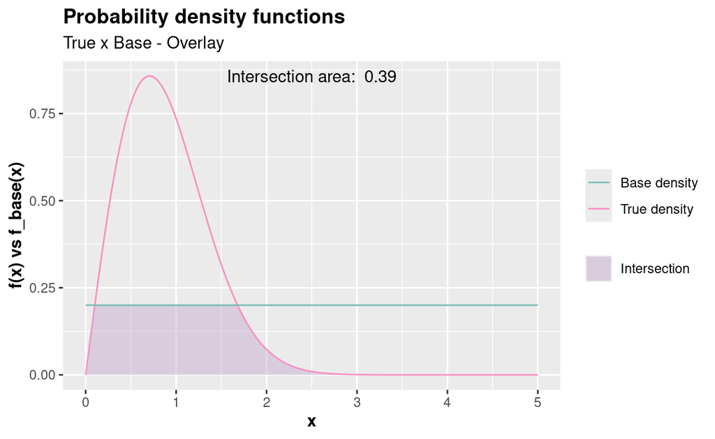

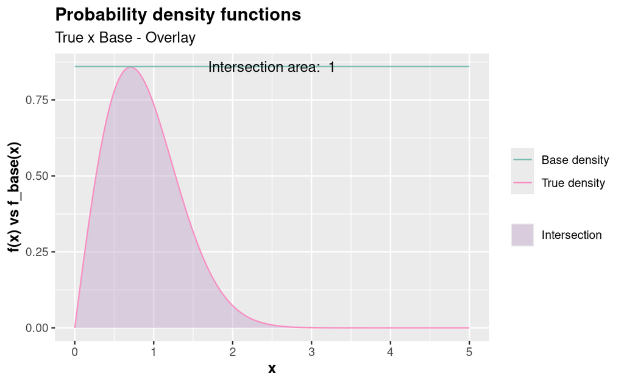

Figure 1: Inspection of the probability density function of the random variable of interest with the base probability density function, with $c = 1$ (default) (a) and $c = 4.3$ (b).

Notice that the support of the base probability density function $g_Y$ must be the same as $f_X$, since the observations generated from $Y$ are accepted or rejected as observations of $X$ (the random variable of interest). The interval $x,y \in [0, 5]$ was chosen because the density near the upper limit of this interval quickly drops to values close to zero, eliminating the need to consider a broader interval, although it could be considered. It is possible to see, with the help of Figure 1 (a), that $c = 1$ is not a good choice, as much of the density $f_X$ would be left out and not captured by $g_Y$, i.e., it would not be bounded by $g_Y$. Therefore, increasing the value of $c$ in this hypothetical example is necessary for good generation of observations of $X$. Note in Figure 1 (a) that the intersection area is approximately 0.39, and in the optimal case, we should have $c \geq 1$, such that the intersection area between $f_X$ and $g_Y$ is 1, and $c$ is the smallest possible value. A small value of $c$ will always imply a higher probability of accepting observations of $Y$ as observations of $X$. Thus, the choice of $c$ will be a trade-off between computational efficiency (higher acceptance probability) and ensuring that the base density bounds the density of interest.

Note now that for $c = 4.3$, in Figure 1 (b), the intersection area is equal to $1$ and $g_Y$ does not excessively bound $f_X$, thus becoming a convenient value. In this way, $c = 4.3$ could be an appropriate value for the given example. However, a larger value of $c$ could be used, which would decrease the computational efficiency of ARM, for reasons that will be presented later.

What makes the method interesting is that the iterations of ARM are not mathematically dependent, making it easily parallelizable. Although it can be extended to the bivariate or multivariate case, the method is most commonly used to generate univariate observations. Moreover, if the distribution of the random variable from which pseudo-random observations are to be generated is indexed by many parameters, ARM can be applied without major impacts, as the number of parameters usually does not affect the efficiency of the method.

Considering the discrete case, suppose $X$ and $Y$ are random variables with probability density function (pdf) or probability function (pf) $f$ and $g$, respectively. Furthermore, suppose there exists a constant $c$ such that

$$\frac{f(x)}{g(y)} \leq c,$$
for every value of $x$, with $f(x) > 0$. To use the acceptance-rejection method to generate observations of the random variable $X$, using the algorithm below, first find a random variable $Y$ with pdf or pf $g$, such that it satisfies the above condition.

It is important that the chosen random variable $Y$ is such that you can easily generate its observations. This is because the acceptance-rejection method is computationally more intensive than more direct methods such as the transformation method or the inversion method, which only requires the generation of pseudo-random numbers with a uniform distribution.

**Algorithm of the Acceptance-Rejection Method**:

1 - Generate an observation $y$ from a random variable $Y$ with pdf/pf $g$;

2 - Generate an observation $u$ from a random variable $U\sim \mathcal{U} (0, 1)$;

3 - If $u < \frac{f(y)}{cg(y)}$ accept $x = y$; otherwise, reject $y$ as an observation of the random variable $X$ and go back to step 1.

**Proof**: Consider the discrete case, that is, $X$ and $Y$ are random variables with pfs $f$ and $g$, respectively. By step 3 of the algorithm above, we have $\{accept\} = \{x = y\} = u < \frac{f(y)}{cg(y)}$. That is,

$$P(accept | Y = y) = \frac{P(accept \cap \{Y = y\})}{g(y)} = \frac{P(U \leq f(y)/cg(y)) \times g(y)}{g(y)} = \frac{f(y)}{cg(y)}.$$
Hence, by the [**Law of Total Probability**](https://en.wikipedia.org/wiki/Law_of_total_probability), we have:

$$P(accept) = \sum_y P(accept|Y=y)\times P(Y=y) = \sum_y \frac{f(y)}{cg(y)}\times g(y) = \frac{1}{c}.$$
Therefore, by the acceptance-rejection method, we accept the occurrence of $Y$ as an occurrence of $X$ with probability $1/c$. Moreover, by Bayes’ Theorem, we have

$$P(Y = y | accept) = \frac{P(accept|Y = y)\times g(y)}{P(accept)} = \frac{[f(y)/cg(y)] \times g(y)}{1/c} = f(y).$$
The result above shows that accepting $x = y$ by the algorithm’s procedure is equivalent to accepting a value from $X$ that has pf $f$. For the continuous case, the proof is similar.

Notice that to reduce the computational cost of the method, we should choose $c$ in such a way that we can maximize $P(accept)$. Therefore, choosing an excessively large value of the constant $c$ will reduce the probability of accepting an observation from $Y$ as an observation of the random variable $X$.

Computationally, it is convenient to consider $Y$ as a random variable with a uniform distribution on the support of $f$, since generating observations from a uniform distribution is straightforward on any computer. For the discrete case, considering $Y$ with a discrete uniform distribution might be a good alternative.

Choosing an excessively large value for $c$ will increase the chances of generating good observations of $X$, as an excessive value for $c$, in many situations, will allow the base distribution $g$ to bound $f$. The problem, however, will be the computational cost. Thus, the problem of choosing an appropriate value for $c$ is an optimization problem, where selecting an appropriate value for $c$ is a task that can be automated. Additionally, it is important to note that choosing an excessively large value for the constant $c$, although it will lead to excessively slow code, is not as significant a problem as choosing an excessively small value for $c$, which will lead to the generation of poor observations of $X$. Since it is an optimization problem, it is possible to choose a convenient value for $c$ that is neither too large nor too small, generating good observations for $X$ with a very acceptable computational cost.

Therefore, the AcceptReject package aims to automate some tasks, including the optimization of the value of $c$. Thus, it becomes clear that, given a probability density function (continuous case) or probability mass function (discrete case) $g$, obtaining the smallest value of $c$, such that $c \geq 1$, combined with the possibility of code parallelism, are excellent ways to reduce the computational cost of ARM. This is, among other things, what the AcceptReject package does through its [`accept_reject()`](https://prdm0.github.io/AcceptReject/reference/accept_reject.html) function and other available functions. In the following sections, we will discuss each of them in detail.

The first article describing the acceptance-rejection method is by von Neumann, titled “Various techniques used in connection with random digits” from 1951 (von Neumann 1951). Several common books in the field of stochastic simulations and Monte Carlo methods also detail the method, such as (Kroese et al. 2013), (Asmussen and Glynn 2007), (Kemp 2003), and (Gentle 2003).